# 🖥️ AI-Powered Financial Insights

Pada kesempatan kali ini, kita akan mencoba menscrap data saham dengan menggunakan API dan diperbantukan oleh AI (LLM) untuk mendapatkan pemahaman mendalam mengenai saham tersebut sehingga dapat dilakukan analisa finansial lanjutan.

Dengan menggunakan AI, kita bisa:

- Mengambil ringkasan laporan keuangan secara otomatis
- Menjelaskan tren yang terlihat pada grafik keuangan
- Mendeteksi potensi resiko keuangan hanya dari data mentah

### Mengapa menggunakan Large Language Models (LLMs) pada Keuangan (Finance)?

LLM adalah model AI yang dilatih dengan jutaan data teks, sehingga mampu memahami dan menghasilkan teks seperti manusia. Kita mungkin mengenal ChatGPT, Groq atau Claude sebagai contoh LLM.

Dalam konteks keuangan, LLM sangat bermanfaat karena:

- Dapat membaca dan memahami lampiran keuangan berbahasa natural.
- Menjawab pertanyaan tentang kondisi keuangan suatu perusahaan.
- Mengintepretasikan grafik seperti tren revenue atau cashflow.
- Menghasilkan insight keuangan secara otomatis tanpa perlu coding kompleks.

Dengan kata lain, LLM membuat analisis keuangan menjadi lebih **mudah dimengerti, cepat dan efisien** bahkan untuk kita yang tidak memiliki latar belakang keuangan maupun teknis.

#### Tools yang digunakan:

- **Python**: Bahasa pemrograman utama yang digunakan. Mudah dipahami, fleksibel, dan banyak digunakan dalam analisis data serta AI
- **Jupyter Notebook**: Tempat menulis dan menjalankan kode Python. Sangat cocok untuk eksperimen data dan dokumentasi proses analisis.
- **Streamlit**: Framework Python untuk membuat aplikasi web secara cepat. Kita akan menggunakannya untuk membangun dashboard dari data dan insight yang kita miliki.
- **LangChain**: Framework yang memudahkan untuk menghubungkan LLM dengan data.
- **Groq**: Salah satu penyedia LLM yang sangat cepat dan efisien. Keduanya akan digunakan untuk menghasilkan insight otomatis dari data keuangan.
- **Sectors API**: Sumber data keuangan yang akan digunakan. Dengan API ini bisa mengambil data tentang perusahaan, laporan keuangan, dan informasi sektor industri secara real time.

### 🔗 LangChain

[LangChain](https://python.langchain.com/docs/introduction/) adalah framework Python yang memudahkan kita dalam:

- Menyusun prompt
- Menghubungkan LLM dengan data kita
- Menyusun pipeline otomatis dari input hingga output

LangChain sangat cocok untuk membangun alur kerja berbasis LLM, seperti tanya-jawab keuangan, chatbot, atau ringkasan otomatis.

### ⚡ Groq

[Groq](https://console.groq.com/docs/quickstart) adalah layanan yang menyediakan akses ke model-model LLM super cepat seperti LLaMA 3 dan lainnya. Kita akan menggunakan Groq sebagai penyedia model AI-nya.

#### 🔌 What is an API and How It Works

**API (Application Programming Interface)** adalah jembatan yang memungkinkan dua aplikasi berkomunikasi. Bayangkan seperti kita memesan makanan lewat aplikasi, dan restoran mengantarkan pesanan ke rumah — konsep yang sama berlaku saat kita minta data ke server melalui API.

🔁 Cara kerjanya:

- Kita kirim **request** (permintaan data)
- Server API membalas dengan **response** (data, biasanya dalam format JSON)

#### 🌐 Introduction to the Sectors API

[Sectors API](https://sectors.app/api) adalah layanan yang menyediakan berbagai informasi terkait sektor industri dan keuangan perusahaan.

Anggap saja ini sebagai perpustakaan atau sumber data utama kita.Kita bisa melihat semua "menu" data yang tersedia di dokumentasi resmi mereka: https://sectors.app/api

- Melihat daftar subsektor industri
- Mengambil daftar perusahaan berdasarkan subsektor
- Mengakses data keuangan mereka
- dll

### 1. Setting Up Python Environment

Setelah mendapatkan API dari Sectors.app, kita akan menyimpan API key di dalam file .env agar aman dan tidak terlihat langsung pada kode. Untuk membaca file ini, kita gunakan library `dotenv`

```python
from dotenv import load_dotenv
import os

# Gunakan `load_dotenv()` untuk memuat semua variabel dari file .env
load_dotenv()

# Ambil key tersebut dari environment dan simpan dalam variabel.
# Gunakan `os.getenv("NAMA_VARIABEL")` untuk "ambil nilai dari variabel X"
SECTORS_API_KEY = os.getenv("SECTORS_API_KEY")

# Alamat utama API dan header otorisasi akan disimpan dalam variabel sehingga tidak perlu mengetiknya berulang kali.
BASE_URL = "https://api.sectors.app/v1"
HEADERS = {"Authorization": SECTORS_API_KEY}
```

> 💡 `BASE_URL` menyimpan alamat utama API, dan `HEADERS` menyimpan API Key yang akan dikirim saat kita melakukan permintaan ke API.

### 2. Setting Up LangChain and LLMs

Untuk memulai, kita perlu mengimpor dua komponen penting:

- `langchain_groq`: digunakan untuk menghubungkan LangChain dengan model LLM dari Groq.
- `PromptTemplate`: digunakan untuk membuat format pertanyaan atau instruksi yang ingin kita berikan ke AI.

```python
from langchain_groq import ChatGroq
from langchain.prompts import PromptTemplate
```

#### 🧪 Inisialisasi Model LLM

Sebelum bisa menggunakan LLM, kita perlu menginisiasi model-nya terlebih dahulu. Ini seperti menyalakan mesin sebelum digunakan.

Kita butuh 3 parameter utama:

- `groq_api_key`: API Key dari Groq yang kita simpan di file `.env`. Digunakan untuk otorisasi.
- `model_name`: nama model yang ingin kita gunakan. Di sini kita pakai `"llama-3.3-70b-versatile"`, yaitu model besar dan canggih dari Meta yang disediakan Groq. Dokumentasi lengkap model Groq bisa dilihat di: https://console.groq.com/docs
- `temperature`: mengatur tingkat kreativitas jawaban.
  - Semakin **rendah** (misalnya 0.0) → jawaban lebih konsisten dan deterministik.
  - Semakin **tinggi** (misalnya 1.0) → jawaban lebih kreatif dan bervariasi.

📌 Kita menggunakan `0.7` agar hasilnya tetap kreatif namun tidak terlalu liar.

```python
GROQ_API_KEY = os.getenv("GROQ_API_KEY")
```

```python
llm = ChatGroq(
    groq_api_key = GROQ_API_KEY,
    temperature=0.7,
    model_name="llama-3.3-70b-versatile"
)
```

```python
llm
```

```
ChatGroq(client=<groq.resources.chat.completions.Completions object at 0x10efe35f0>, async_client=<groq.resources.chat.completions.AsyncCompletions object at 0x10efe2000>, model_name='llama-3.3-70b-versatile', model_kwargs={}, groq_api_key=SecretStr('**********'))
```

### 3. Building a Prompt-Driven Analysis Pipeline

Prompt adalah masukan, instruksi, atau pertanyaan yang diberikan kepada sistem (terutama pada kecerdasan buatan) untuk menghasilkan suatu respons atau output yang diinginkan. Dalam konteks AI generatif, prompt berfungsi sebagai panduan yang mengarahkan model bahasa besar (LLM) untuk melakukan tugas tertentu, mulai dari perintah sederhana hingga pertanyaan kompleks, dan dapat berupa teks, gambar, atau audio.

```python
#Contoh penerapan sederhana prompt
pertanyaan1 = llm.invoke("Jelaskan apa itu API dalam satu kalimat saja")
pertanyaan1.content
```

```
'API (Application Programming Interface) adalah sebuah antarmuka pemrograman yang memungkinkan berbagai aplikasi atau sistem untuk berkomunikasi dan berbagi data satu sama lain.'
```

> 📌 `invoke()` adalah cara cepat untuk meminta jawaban dari LLM berdasarkan prompt (teks perintah) yang kita kirim.

Kalau kita ingin AI melakukan tugas spesifik berdasarkan pola tertentu, kita bisa membuat *template prompt*.

```python
# `PromptTemplate` untuk membuat format prompt dengan variabel dinamis.
# Perhatikan `{topic}`, ini adalah variabel yang bisa kita isi nanti.

template = PromptTemplate(
    input_variables=["topic"],
    template="Jelaskan apa itu {topic} dalam satu kalimat saja"
)

# Mengisi Variabel
# Isi variabel dinamis yang sudah kita definisikan sebelumnya menggunakan `.format`

prompt = template.format(topic="python")

# Jalankan LLM
llm.invoke(prompt).content
```

```
'Python adalah bahasa pemrograman tingkat tinggi yang mudah dipelajari dan digunakan untuk mengembangkan berbagai aplikasi, termasuk pengolahan data, machine learning, dan pengembangan web.'
```

# 📊 Exploring Financial Insights

Pada tahap ini, kita akan menggabungkan **data keuangan dari API** dengan **kemampuan AI (LLM)** untuk membaca dan menginterpretasikan data tersebut. Kita akan membuat analisis otomatis, visualisasi tren, dan bahkan deteksi risiko keuangan — semua berbasis AI 💡🤖

### 📑 Creating an Automated Financial Summary

Sekarang kita akan mengambil data keuangan dan meminta AI untuk menyusunnya secara otomatis.

##### 1. Mengambil Data Kuartalan

```python
# `/financials/quarterly/` merupakan endpoint yang didapat dari Sectors.app, silahkan mengunjungin websitenya untuk mendapatkan penjelasan dari endpoint tersebut.

# Import library `requests` yang berfungsi sebagai "kurir" untuk mengirim permintaan kita
import requests
# Gunakan `requests.get()` -> perintah untuk "Tolong ambilkan data dari URL ini".


# Import library `pandas` untuk mengubah data hasil tarikan menjadi sebuah dataframe
import pandas as pd

symbol = "CPIN.JK"
url_fin = f"{BASE_URL}/financials/quarterly/{symbol}/"
params = {"n_quarters" : "4",
          "report_date": "2024-09-30"}

# Sertakan `HEADERS` agar server tahu siapa kita.
response = requests.get(url_fin, headers=HEADERS, params=params)

#Ubah data tarikan (response) menjadi sebuah dataframe
financials = pd.DataFrame(response.json())

financials
```

|  | symbol | financials_sector_metrics | date | premium_income | premium_expense | net_premium_income | non_interest_income | revenue | operating_expense | provision | ... | cash_and_short_term_investments | non_loan_assets | total_current_asset | total_non_current_liabilities | financing_cash_flow | operating_cash_flow | investing_cash_flow | net_cash_flow | capital_expenditure | free_cash_flow |
| --- | --- | --- | --- | --- | --- | --- | --- | --- | --- | --- | --- | --- | --- | --- | --- | --- | --- | --- | --- | --- | --- |
| 0 | CPIN.JK | None | 2025-06-30 | None | None | None | 33952000000 | 15356986000000 | 1134481000000 | None | ... | 3381678000000 | None | 21712537000000 | 3992382000000 | -1777007000000 | -464647000000 | -512128000000 | -2753782000000 | 515220000000 | -979867000000 |
| 1 | CPIN.JK | None | 2025-03-31 | None | None | None | 34199000000 | 17704697000000 | 1086894000000 | None | ... | 5773705000000 | None | 22408711000000 | 4063046000000 | -1020427000000 | 2598615000000 | -270501000000 | 1307687000000 | 308390000000 | 2290225000000 |
| 2 | CPIN.JK | None | 2024-12-31 | None | None | None | 19598000000 | 17759266000000 | 1349338000000 | None | ... | 4446488000000 | None | 21339691000000 | 3912506000000 | -1330340000000 | 2237675000000 | 195336000000 | 1102671000000 | 347212000000 | 1890463000000 |
| 3 | CPIN.JK | None | 2024-09-30 | None | None | None | 10517000000 | 16756753000000 | 1088565000000 | None | ... | 3300803000000 | None | 20815703000000 | 3872144000000 | -8407000000 | 1411568000000 | -176782000000 | 1226379000000 | 215159000000 | 1196409000000 |

4 rows × 40 columns

##### 2. Prompt Template untuk Ringkasan Keuangan

Dilakukan untuk memandu AI memberikan ringkasan yang berkualitas dan lebih spesifik terhadap pertanyaan.

> **✨ Pro Tips**: Daripada hanya meminta ringkasan, kita beri AI sebuah peran (sebagai analis) dan instruksi yang jelas (fokus pada pendapatan, laba, dan arus kas).

```python
prompt_summary_template = PromptTemplate.from_template(
    """
    Anda adalah seorang analis keuangan yang handal.
    Berdasarkan data keuangan kuartalan berikut (dalam miliar Rupiah):

    {data}

    Tuliskan ringkasan eksekutif dalam 3 poin singkat untuk seorang investor.
    Fokus pada:
    1. Tren pertumbuhan pendapatan (revenue)
    2. Tingkat profitabilitas
    3. Posisi arus kas operasi
    """
)


# Eksekusi dan hasilkan ringkasan dari LLM:
prompt_summary = prompt_summary_template.format(data = financials)
print(llm.invoke(prompt_summary).content)
```

[output not shown]

##### 3. 📈 Visualizing Revenue Trends

LLM juga bisa diminta untuk menulis kode visualisasi berdasarkan data.

Kita mulai dengan mengambil bagian yang relevan:

```python
sample_data_viz = financials[['date','revenue']]
sample_data_viz.head()
```

|  | date | revenue |
| --- | --- | --- |
| 0 | 2025-06-30 | 15356986000000 |
| 1 | 2025-03-31 | 17704697000000 |
| 2 | 2024-12-31 | 17759266000000 |
| 3 | 2024-09-30 | 16756753000000 |

```python
template_viz = PromptTemplate.from_template(
    """
    Anda adalah seorang programmer Python yang ahli dalam visualisasi data.

    Berikut adalah data perdapatan perusahaan:

    {data}

    Buat sebuah skrip Python menggunakan matplotlib untuk menghasilkan line plot.
    Instruksi:
    - Sumbu X adalah 'date'
    - Sumbu Y adalah 'revenue'

    Tulis HANYA kode Python yang bisa langsung dieksekusi. Jangan sertakan penjelasan apapun.
    """
)

#Minta LLM menghasilkan kodenya:
llm_viz = llm.invoke(template_viz.format(data=sample_data_viz)).content
print(llm_viz)
```

````
```python
import pandas as pd
import matplotlib.pyplot as plt
import matplotlib.dates as mdates

# Membuat dataframe
data = {
    'date': ['2025-06-30', '2025-03-31', '2024-12-31', '2024-09-30'],
    'revenue': [15356986000000, 17704697000000, 17759266000000, 16756753000000]
}
df = pd.DataFrame(data)

# Mengkonversi kolom 'date' ke datetime
df['date'] = pd.to_datetime(df['date'])

# Membuat line plot
plt.figure(figsize=(10, 6))
plt.plot(df['date'], df['revenue'], marker='o')

# Mengatur format sumbu X
plt.gca().xaxis.set_major_formatter(mdates.DateFormatter('%Y-%m-%d'))
plt.gcf().autofmt_xdate()

# Mengatur judul dan label sumbu
plt.title('Perdapatan Perusahaan')
plt.xlabel('Tanggal')
plt.ylabel('Pendapatan')

# Menampilkan plot
plt.show()
```
````

````python
# Melakukan pembersihan output LLM karena kode masih terbungkus dalam ```python ... ```
clean_code = llm_viz.strip().strip("```python").strip()
clean_code
````

[output not shown]

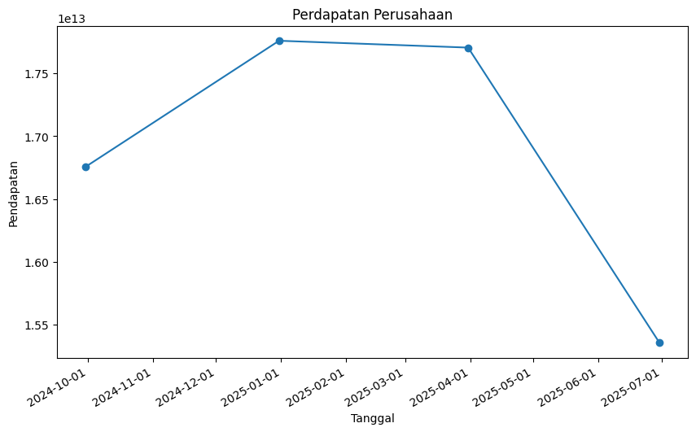

```python
#Gunakan `exec()` untuk menjalankan kode yang berbentuk string

exec(clean_code)
```

##### 4. 🔎 Interpreting Key Financial Trends

Meminta LLM untuk menganalisis tren dari data revenue, laba bersih dan arus kas operasional.

```python
template_trend = PromptTemplate.from_template(
    """
    Bertindaklah sebagai seorang analis keuangan.
    Berdasarkan data kuartalan berikut:
    {data}
    Analisis tren utama yang muncul dari data tersebut. Fokus pada pergerakan revenue, net_income, dan operating.
    Sajikan analisis dalam 3 poin. Tuliskan dalam bahasa yang singkat, padat, jelas
    """
)

interpretasi_tren = llm.invoke(template_trend.format(data=financials))
print(interpretasi_tren.content)
```

```
Berikut adalah analisis tren utama dari data keuangan:

* **Pendapatan**: Pendapatan (revenue) mengalami fluktuasi, dengan nilai tertinggi pada kuartal 2025-03-31 sebesar 17,704 triliun dan terendah pada kuartal 2024-09-30 sebesar 16,757 triliun.
* **Beban Operasional**: Beban operasional (operating_expense) juga mengalami fluktuasi, dengan nilai tertinggi pada kuartal 2024-12-31 sebesar 13,493 triliun dan terendah pada kuartal 2025-03-31 sebesar 10,869 triliun.
* **Arus Kas Operasional**: Arus kas operasional (operating_cash_flow) menunjukkan tren positif, dengan nilai tertinggi pada kuartal 2025-03-31 sebesar 2,598 triliun dan terendah pada kuartal 2025-06-30 sebesar -464 miliar.
```

##### 5. ⚠️ Detecting Potential Financial Risks

Meminta LLM untuk mencari potensi risiko yang mungkin tersembunyi dalam laporan keuangan.

Seorang analis yang baik tidak hanya melihat sisi positif, tetapi juga potensi risiko. Mari kita suruh AI untuk menjadi "skeptis" dan mencari potensi masalah.

**✨Pro Tips**: Kita minta AI untuk berperan sebagai analis risiko dan mencari red flags spesifik. Ini akan menghasilkan jawaban yang lebih tajam dan tidak generik.

```python
template_risk = PromptTemplate.from_template(
    """
    Anda adalah seorang analis risiko keuangan yang skeptis.
    Periksa data keuangan berikut dengan teliti:
    {data}
    Indentifikasi 2-3 potensi risiko atau "red flags" yang perlu diwaspadai dari data tersebut.
    Jelaskan dalam satu kalimat singkat

    """
)

llm_risiko = llm.invoke(template_risk.format(data=financials))
print(llm_risiko.content)
```

```
Beberapa potensi risiko atau "red flags" yang perlu diwaspadai dari data tersebut adalah adanya nilai-nilai kosong (None) pada beberapa kolom yang penting, seperti premium_income dan provision, serta fluktuasi besar pada beberapa jenis arus kas, seperti financing_cash_flow dan operating_cash_flow.
```

## Kesimpulan

Secara keseluruhan, integrasi Python, LLM, LangChain dan Groq menciptakan alur kerja (workflow) analisis finansial yang kuat dan terotomatisasi. Alih-alih melakukan analisis manual yang memakan waktu, sistem ini dapat dengan cepat memproses data, mengidentifikasi tren dan bahkan memberikan wawasan yang dapat ditindaklanjuti. Ini memungkinkan para analis keuangan untuk fokus pada strategi dan pengambilan keputusan, bukan pada pekerjaan data yang repetitif.

*Sumber:*

*- Dwi Gustin Nurdialit - Algoritma Data Science School, 2025*

*- Python*

*- Sectors.app*

*- LangChain*

*- Groq*